# Regression

# Libraries

Load in our packages

```r
library(MASS) # Contains our data
library(ISLR2) # Contains the Boston data set
```

Let’s glimpse our dataset

```r
head(Boston)
```

```
##      crim zn indus chas   nox    rm  age    dis rad tax ptratio lstat medv
## 1 0.00632 18  2.31    0 0.538 6.575 65.2 4.0900   1 296    15.3  4.98 24.0
## 2 0.02731  0  7.07    0 0.469 6.421 78.9 4.9671   2 242    17.8  9.14 21.6
## 3 0.02729  0  7.07    0 0.469 7.185 61.1 4.9671   2 242    17.8  4.03 34.7
## 4 0.03237  0  2.18    0 0.458 6.998 45.8 6.0622   3 222    18.7  2.94 33.4
## 5 0.06905  0  2.18    0 0.458 7.147 54.2 6.0622   3 222    18.7  5.33 36.2
## 6 0.02985  0  2.18    0 0.458 6.430 58.7 6.0622   3 222    18.7  5.21 28.7
```

Output variable:

- Medv: medium house value. Our predictor variable

Input variables: - rmvar - average number of rooms per house - age average age of house - lstat - percent of households with low socioeconomic status

# Simple Linear Regression

Let’s use the `attach` command to lock on our data set

```r
attach(Boston)
```

We can use the `lm` function to fit a simple linear regression model

```r
lm_fit <- lm(medv ~ lstat)
```

We can view some of the characteristics of the model

```r
lm_fit
```

```
##
## Call:
## lm(formula = medv ~ lstat)
##
## Coefficients:
## (Intercept)        lstat
##       34.55        -0.95
```

For more detail information, we use `summary` function to give us the *p*-values and standard errors for the coefficients and the R^2 statistic and *F*-statistics

```r
summary(lm_fit)
```

```
##
## Call:
## lm(formula = medv ~ lstat)
##
## Residuals:
##     Min      1Q  Median      3Q     Max
## -15.168  -3.990  -1.318   2.034  24.500
##
## Coefficients:
##             Estimate Std. Error t value Pr(>|t|)
## (Intercept) 34.55384    0.56263   61.41   <2e-16 ***
## lstat       -0.95005    0.03873  -24.53   <2e-16 ***
## ---
## Signif. codes:  0 '***' 0.001 '**' 0.01 '*' 0.05 '.' 0.1 ' ' 1
##
## Residual standard error: 6.216 on 504 degrees of freedom
## Multiple R-squared:  0.5441, Adjusted R-squared:  0.5432
## F-statistic: 601.6 on 1 and 504 DF,  p-value: < 2.2e-16
```

We can use the `names()` function to find out more information in our model.

```r
names(lm_fit)
```

```
##  [1] "coefficients"  "residuals"     "effects"       "rank"
##  [5] "fitted.values" "assign"        "qr"            "df.residual"
##  [9] "xlevels"       "call"          "terms"         "model"
```

We can also use the `coef()` function to find out the coefficients

```r
coef(lm_fit)
```

```
## (Intercept)       lstat
##  34.5538409  -0.9500494
```

The `confint()` function shows us confidence intervals

```r
confint(lm_fit)
```

```
##                 2.5 %     97.5 %
## (Intercept) 33.448457 35.6592247
## lstat       -1.026148 -0.8739505
```

The `predict()` function shows us CI and prediction intervals for the prediction of `medv` for a given value of `lstat`

```r
predict(lm_fit, data.frame(lstat = (c(5, 10, 50))),
    interval = "confidence")
```

```
##         fit       lwr       upr
## 1  29.80359  29.00741  30.59978
## 2  25.05335  24.47413  25.63256
## 3 -12.94863 -15.84207 -10.05518
```

```r
predict(lm_fit, data.frame(lstat = (c(5, 10, 15))),
    interval = "prediction")
```

```
##        fit       lwr      upr
## 1 29.80359 17.565675 42.04151
## 2 25.05335 12.827626 37.27907
## 3 20.30310  8.077742 32.52846
```

For example, the 95% CI associated with an `lstat` value of 10 is (24.47, 25. 63), and the 95% prediction interval is (12.83, 37.28).

## Creating our plots

We plot `medv` and `lstat` along with the least squares regression line using `plot` and `abline` functions

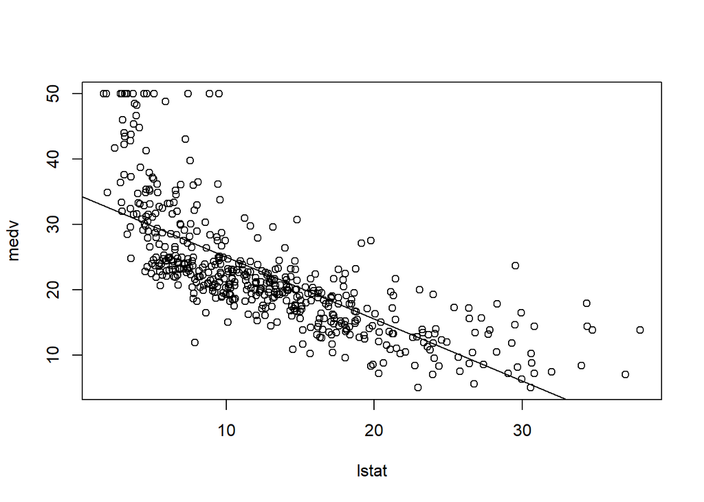

```r
plot(lstat, medv)
abline(lm_fit)
```

By looking at the data, there is some evidence for non-linearity - we will explore this later.

The `abline()` function can be used to draw any line, not just the least squares regression line.

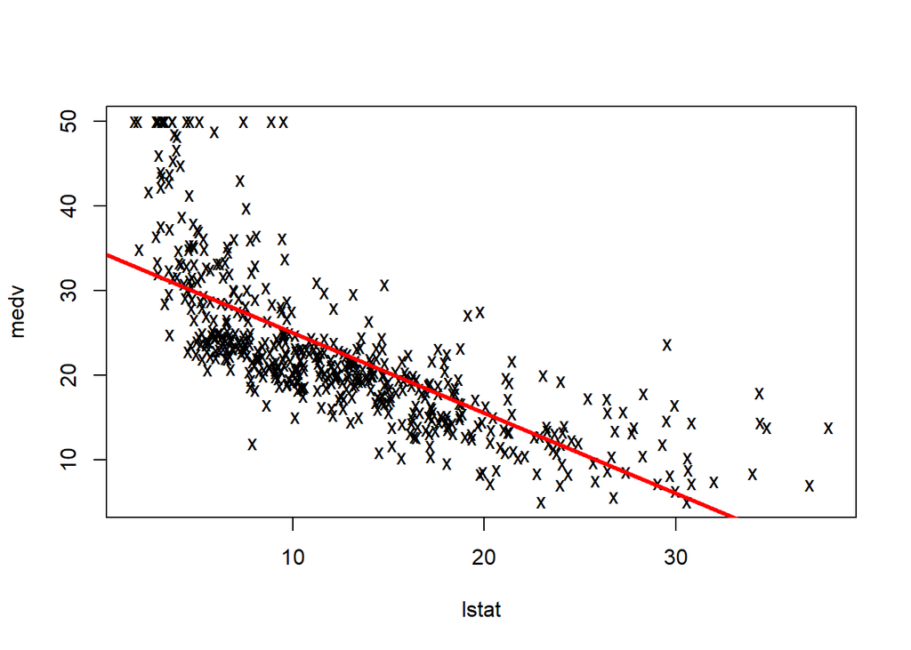

```r
plot(lstat, medv, pch = "x")
abline(lm_fit, lwd = 3, col = "red")
```

## Diagnostic plots

We can create some Diagnostic plots using the `plot()` function to `lm_fit`. We can use the `par()` function and `mrow()` argument to tell R to split the plots into separate panels so we can view multiple plots are once.

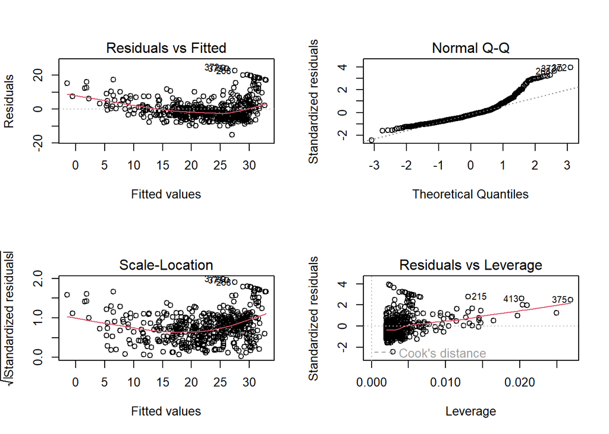

```r
par(mfrow = c(2, 2))
plot(lm_fit)
```

On the basis of the residuals vs fitted plot, there is some evidence of non-linearity. Leverage statisticcan be computer for any number of predictors using the `hatvalues()` function

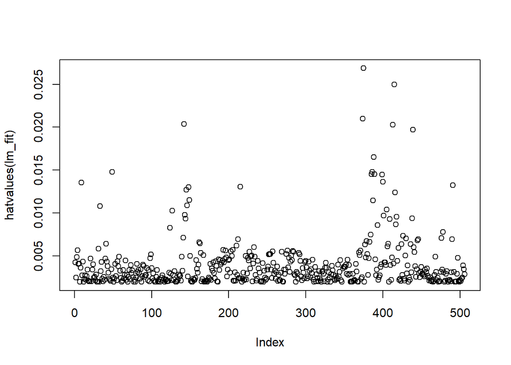

```r
par(mfrow = c(1, 1))
plot(hatvalues(lm_fit))
```

The `which.max()` function identifies the index of the largest element of a vector. In this case it tells us which observation has the largest leverage statistic.

```r
which.max(hatvalues(lm_fit))
```

```
## 375
## 375
```

# Multiple Regression

To fit a multiple linear regression model using least squares, we again need to use the `lm()` function.

```r
mult_model <- lm(medv ~ lstat + age)
summary(mult_model)
```

```
##
## Call:
## lm(formula = medv ~ lstat + age)
##
## Residuals:
##     Min      1Q  Median      3Q     Max
## -15.981  -3.978  -1.283   1.968  23.158
##
## Coefficients:
##             Estimate Std. Error t value Pr(>|t|)
## (Intercept) 33.22276    0.73085  45.458  < 2e-16 ***
## lstat       -1.03207    0.04819 -21.416  < 2e-16 ***
## age          0.03454    0.01223   2.826  0.00491 **
## ---
## Signif. codes:  0 '***' 0.001 '**' 0.01 '*' 0.05 '.' 0.1 ' ' 1
##
## Residual standard error: 6.173 on 503 degrees of freedom
## Multiple R-squared:  0.5513, Adjusted R-squared:  0.5495
## F-statistic:   309 on 2 and 503 DF,  p-value: < 2.2e-16
```

If we want to add our of our predictor, we can instead use `.,`

```r
mult_model <- lm(medv ~ ., data = Boston)
summary(mult_model)
```

```
##
## Call:
## lm(formula = medv ~ ., data = Boston)
##
## Residuals:
##      Min       1Q   Median       3Q      Max
## -15.1304  -2.7673  -0.5814   1.9414  26.2526
##
## Coefficients:
##               Estimate Std. Error t value Pr(>|t|)
## (Intercept)  41.617270   4.936039   8.431 3.79e-16 ***
## crim         -0.121389   0.033000  -3.678 0.000261 ***
## zn            0.046963   0.013879   3.384 0.000772 ***
## indus         0.013468   0.062145   0.217 0.828520
## chas          2.839993   0.870007   3.264 0.001173 **
## nox         -18.758022   3.851355  -4.870 1.50e-06 ***
## rm            3.658119   0.420246   8.705  < 2e-16 ***
## age           0.003611   0.013329   0.271 0.786595
## dis          -1.490754   0.201623  -7.394 6.17e-13 ***
## rad           0.289405   0.066908   4.325 1.84e-05 ***
## tax          -0.012682   0.003801  -3.337 0.000912 ***
## ptratio      -0.937533   0.132206  -7.091 4.63e-12 ***
## lstat        -0.552019   0.050659 -10.897  < 2e-16 ***
## ---
## Signif. codes:  0 '***' 0.001 '**' 0.01 '*' 0.05 '.' 0.1 ' ' 1
##
## Residual standard error: 4.798 on 493 degrees of freedom
## Multiple R-squared:  0.7343, Adjusted R-squared:  0.7278
## F-statistic: 113.5 on 12 and 493 DF,  p-value: < 2.2e-16
```

We can also remove variables using `-`

```r
mult_model <- lm(medv ~ . - age, data = Boston)
```

Alternatively, the `update` function can be used

```r
mult_model <- update(mult_model, ~ . - age)
```

We can access individual features of a summary object by name using `$`

```r
summary(mult_model)$r.sq
```

```
## [1] 0.7342675
```

The `vif()` function from the `car` package can be used to compute variance inflation factors.

```r
library(car)
vif(mult_model)
```

```
##     crim       zn    indus     chas      nox       rm      dis      rad
## 1.767455 2.265259 3.987176 1.068018 4.070020 1.834792 3.613722 7.396707
##      tax  ptratio    lstat
## 8.994939 1.785403 2.546740
```

# Interaction Terms

We can add interaction terms within `lm()` using `*`.

```r
summary(lm(medv ~ lstat * age, data = Boston))
```

```
##
## Call:
## lm(formula = medv ~ lstat * age, data = Boston)
##
## Residuals:
##     Min      1Q  Median      3Q     Max
## -15.806  -4.045  -1.333   2.085  27.552
##
## Coefficients:
##               Estimate Std. Error t value Pr(>|t|)
## (Intercept) 36.0885359  1.4698355  24.553  < 2e-16 ***
## lstat       -1.3921168  0.1674555  -8.313 8.78e-16 ***
## age         -0.0007209  0.0198792  -0.036   0.9711
## lstat:age    0.0041560  0.0018518   2.244   0.0252 *
## ---
## Signif. codes:  0 '***' 0.001 '**' 0.01 '*' 0.05 '.' 0.1 ' ' 1
##
## Residual standard error: 6.149 on 502 degrees of freedom
## Multiple R-squared:  0.5557, Adjusted R-squared:  0.5531
## F-statistic: 209.3 on 3 and 502 DF,  p-value: < 2.2e-16
```

# Non-linear Transformations of the predictors

The `lm()` function can also accomodate non-linear transformations of the predictors. For a given predictor *X*, we can create a predictor *X*^2 using `I(X^2)`. The function `I()` is needed since the `^` has a special meaning.

```r
lm_fit_non_lin <- lm(medv ~ lstat + I(lstat^2))
summary(lm_fit_non_lin)
```

```
##
## Call:
## lm(formula = medv ~ lstat + I(lstat^2))
##
## Residuals:
##      Min       1Q   Median       3Q      Max
## -15.2834  -3.8313  -0.5295   2.3095  25.4148
##
## Coefficients:
##              Estimate Std. Error t value Pr(>|t|)
## (Intercept) 42.862007   0.872084   49.15   <2e-16 ***
## lstat       -2.332821   0.123803  -18.84   <2e-16 ***
## I(lstat^2)   0.043547   0.003745   11.63   <2e-16 ***
## ---
## Signif. codes:  0 '***' 0.001 '**' 0.01 '*' 0.05 '.' 0.1 ' ' 1
##
## Residual standard error: 5.524 on 503 degrees of freedom
## Multiple R-squared:  0.6407, Adjusted R-squared:  0.6393
## F-statistic: 448.5 on 2 and 503 DF,  p-value: < 2.2e-16
```

The near-zero *p* value associated with the quadratic term suggests that it leads to an improved model. We use the `anova()` function to assess which fit is superior

```r
lm_fit <- lm(medv ~ lstat)
anova(lm_fit, lm_fit_non_lin)
```

```
## Analysis of Variance Table
##
## Model 1: medv ~ lstat
## Model 2: medv ~ lstat + I(lstat^2)
##   Res.Df   RSS Df Sum of Sq     F    Pr(>F)
## 1    504 19472
## 2    503 15347  1    4125.1 135.2 < 2.2e-16 ***
## ---
## Signif. codes:  0 '***' 0.001 '**' 0.01 '*' 0.05 '.' 0.1 ' ' 1
```

The `anova()` function performs a hypothesis test comparing the two models. The null hypothesis is that both models fit the data equally well, and the alternate hypothesis is that the full model is superior. The associated *p*-value is nearly zero. This provides clear evidence that the model containing the predictors `lstat` and `lstat^2 is far superior. This is not surprising, since we saw evidence for non-linearity in the relationship between`medv`and`lstat`.

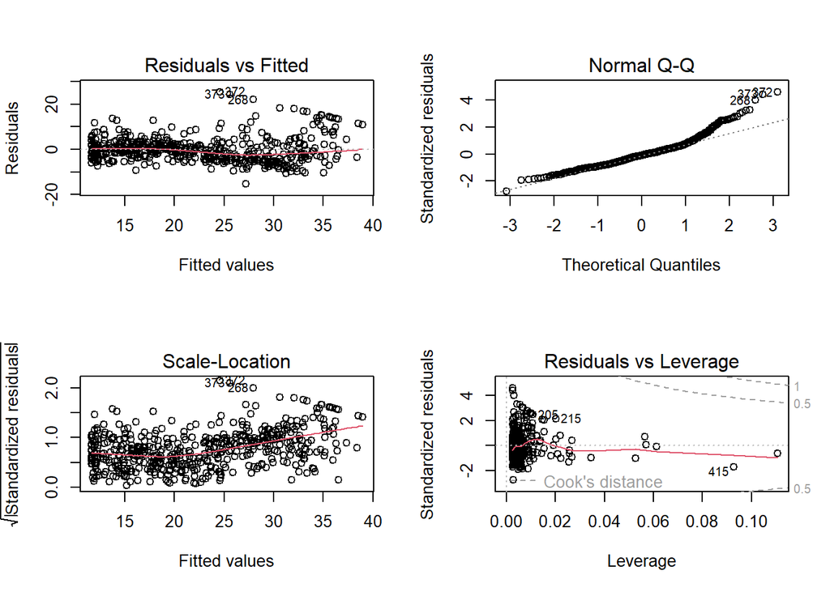

```r
par(mfrow = c(2, 2))
plot(lm_fit_non_lin)
```

Our residuals look much better, there is little discernible pattern in the residuals.

## Cubic fit

In order to create a cubic fit, we can include a predictor or the form `I(X^2)`. However, this approach can start to get cumbersome for higher order polynomials. A better approach involves using the `poly()` function to create the polynomial with `lm()`.

```r
poly_5 <- lm(medv ~ poly(lstat, 5))
summary(poly_5)
```

```
##
## Call:
## lm(formula = medv ~ poly(lstat, 5))
##
## Residuals:
##      Min       1Q   Median       3Q      Max
## -13.5433  -3.1039  -0.7052   2.0844  27.1153
##
## Coefficients:
##                  Estimate Std. Error t value Pr(>|t|)
## (Intercept)       22.5328     0.2318  97.197  < 2e-16 ***
## poly(lstat, 5)1 -152.4595     5.2148 -29.236  < 2e-16 ***
## poly(lstat, 5)2   64.2272     5.2148  12.316  < 2e-16 ***
## poly(lstat, 5)3  -27.0511     5.2148  -5.187 3.10e-07 ***
## poly(lstat, 5)4   25.4517     5.2148   4.881 1.42e-06 ***
## poly(lstat, 5)5  -19.2524     5.2148  -3.692 0.000247 ***
## ---
## Signif. codes:  0 '***' 0.001 '**' 0.01 '*' 0.05 '.' 0.1 ' ' 1
##
## Residual standard error: 5.215 on 500 degrees of freedom
## Multiple R-squared:  0.6817, Adjusted R-squared:  0.6785
## F-statistic: 214.2 on 5 and 500 DF,  p-value: < 2.2e-16
```

This suggests that including additional polynomial terms leads to an improvement in the model fit. However, further investigation of the data reveals that no polynomial terms beyond the fifth order have significant *p*-values in a regression fit.

We can also try a log transformation

```r
summary(lm(medv ~ log(rm), data = Boston))
```

```
##
## Call:
## lm(formula = medv ~ log(rm), data = Boston)
##
## Residuals:
##     Min      1Q  Median      3Q     Max
## -19.487  -2.875  -0.104   2.837  39.816
##
## Coefficients:
##             Estimate Std. Error t value Pr(>|t|)
## (Intercept)  -76.488      5.028  -15.21   <2e-16 ***
## log(rm)       54.055      2.739   19.73   <2e-16 ***
## ---
## Signif. codes:  0 '***' 0.001 '**' 0.01 '*' 0.05 '.' 0.1 ' ' 1
##
## Residual standard error: 6.915 on 504 degrees of freedom
## Multiple R-squared:  0.4358, Adjusted R-squared:  0.4347
## F-statistic: 389.3 on 1 and 504 DF,  p-value: < 2.2e-16
```

# Qualitative predictors

Let’s have a look at the `Carseats` data:

```r
head(Carseats)
```

```
##   Sales CompPrice Income Advertising Population Price ShelveLoc Age Education
## 1  9.50       138     73          11        276   120       Bad  42        17
## 2 11.22       111     48          16        260    83      Good  65        10
## 3 10.06       113     35          10        269    80    Medium  59        12
## 4  7.40       117    100           4        466    97    Medium  55        14
## 5  4.15       141     64           3        340   128       Bad  38        13
## 6 10.81       124    113          13        501    72       Bad  78        16
##   Urban  US
## 1   Yes Yes
## 2   Yes Yes
## 3   Yes Yes
## 4   Yes Yes
## 5   Yes  No
## 6    No Yes
```

The qualitative predictor `shelveloc` indicates the shelving location, either bad, medium, and good. R generates dummy variables automatically

```r
qual_fit <- lm(Sales ~ . + Income:Advertising + Price:Age, data = Carseats)
summary(qual_fit)
```

```
##
## Call:
## lm(formula = Sales ~ . + Income:Advertising + Price:Age, data = Carseats)
##
## Residuals:
##     Min      1Q  Median      3Q     Max
## -2.9208 -0.7503  0.0177  0.6754  3.3413
##
## Coefficients:
##                      Estimate Std. Error t value Pr(>|t|)
## (Intercept)         6.5755654  1.0087470   6.519 2.22e-10 ***
## CompPrice           0.0929371  0.0041183  22.567  < 2e-16 ***
## Income              0.0108940  0.0026044   4.183 3.57e-05 ***
## Advertising         0.0702462  0.0226091   3.107 0.002030 **
## Population          0.0001592  0.0003679   0.433 0.665330
## Price              -0.1008064  0.0074399 -13.549  < 2e-16 ***
## ShelveLocGood       4.8486762  0.1528378  31.724  < 2e-16 ***
## ShelveLocMedium     1.9532620  0.1257682  15.531  < 2e-16 ***
## Age                -0.0579466  0.0159506  -3.633 0.000318 ***
## Education          -0.0208525  0.0196131  -1.063 0.288361
## UrbanYes            0.1401597  0.1124019   1.247 0.213171
## USYes              -0.1575571  0.1489234  -1.058 0.290729
## Income:Advertising  0.0007510  0.0002784   2.698 0.007290 **
## Price:Age           0.0001068  0.0001333   0.801 0.423812
## ---
## Signif. codes:  0 '***' 0.001 '**' 0.01 '*' 0.05 '.' 0.1 ' ' 1
##
## Residual standard error: 1.011 on 386 degrees of freedom
## Multiple R-squared:  0.8761, Adjusted R-squared:  0.8719
## F-statistic:   210 on 13 and 386 DF,  p-value: < 2.2e-16
```

The `contrasts()` function returns the coding the `R` uses the for dummy variables

```r
attach(Carseats)
contrasts(ShelveLoc)
```

```
##        Good Medium
## Bad       0      0
## Good      1      0
## Medium    0      1
```